# Issues to calculate sensitivity and specificity of GWA studies

Jose Alquicira Hernandez

11/05/2015

# rs2573905 | Alzheimer’s disease

### Populations: Cases and controls

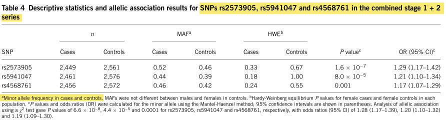

Sum of cases and controls for initial and replication sample:

N° Cases = 2391

N° Controls = 2464

The number of cases and controls to be considered will be the ones reported in the previous table.

**N° Cases = 2449**

**N° Controls = 2561**

### Risk allele frequency

The risk allele frequency is the same in the paper.

|  | 2_rs2573905 |
| --- | --- |
| PUBMEDID | 19136949 |
| LINK | http://europepmc.org/abstract/MED/19136949 |
| STUDY | Genetic variation in PCDH11X is associated with susceptibility to late-onset Alzheimer’s disease. |
| DISEASE.TRAIT | Alzheimer’s disease |
| INITIAL.SAMPLE.DESCRIPTION | 844 European ancestry cases, 1,255 European ancestry controls |
| REPLICATION.SAMPLE.DESCRIPTION | 1,547 European ancestry cases, 1,209 European ancestry controls |
| STRONGEST.SNP_RISK.ALLELE | rs2573905-? |
| SNPS | rs2573905 |
| RISK.ALLELE.FREQUENCY | 0.46 |
| P.VALUE | 2e-07 |
| ORorBETA | 1.29 |
| STAGE | 1+2 \| combined |
| CLINICAL.VARIABLES | NA |
| NOTES | NA |
| Sensitivity | 0.5235574 |
| Specificity | 0.54 |

|  | Cases | Controls |
| --- | --- | --- |
| ? (+) | 1282 | 1178 |
| ? ( - ) | 1167 | 1383 |
| Total | 2449 | 2561 |

# rs11136000 | Alzheimer’s disease

### Populations: Cases and controls

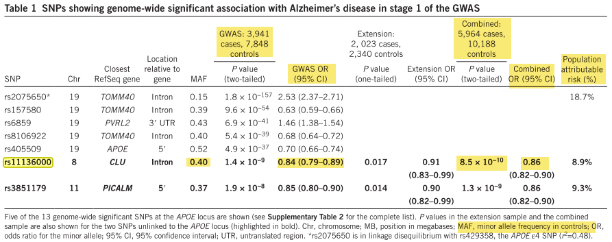

### Risk allele frequency

The MAF for the first phase is reported for this SNP, but the RAF for the combined phase does not. We will consider the sample size for controls and cases from the first phase: 3941 cases and 7848 controls and the corresponding odd ratio 1/0.84 = 1.1904762. The MAF reported corresponds in the paper corresponds to the minor allele in controls, so RAF in the catalog will be preserved.

|  | 3_rs11136000 |
| --- | --- |
| PUBMEDID | 19734902 |
| LINK | http://europepmc.org/abstract/MED/19734902 |
| STUDY | Genome-wide association study identifies variants at CLU and PICALM associated with Alzheimer’s disease. |
| DISEASE.TRAIT | Alzheimer’s disease |
| INITIAL.SAMPLE.DESCRIPTION | 3,941 European ancestry cases, 7,848 European ancestry controls |
| REPLICATION.SAMPLE.DESCRIPTION | 2,023 European ancestry cases, 2,340 European ancestry controls |
| STRONGEST.SNP_RISK.ALLELE | rs11136000-? |
| SNPS | rs11136000 |
| RISK.ALLELE.FREQUENCY | 0.6 |
| P.VALUE | 1e-09 |
| ORorBETA | 1.19 |
| STAGE | 1 |
| CLINICAL.VARIABLES | NA |
| NOTES | Heritability of up to 76% for Alzheimer’s disease \| Flipped odd ratio \| Population attributable risk reported |
| Sensitivity | 0.6409336 |
| Specificity | 0.4 |

|  | Cases | Controls |
| --- | --- | --- |
| ? (+) | 2526 | 4709 |
| ? ( - ) | 1415 | 3139 |
| Total | 3941 | 7848 |

The same assumptions are considerated for the remaining SNPs of this study.

# rs2075650 | Alzheimer’s disease

|  | 4_rs2075650 |
| --- | --- |
| PUBMEDID | 19734902 |
| LINK | http://europepmc.org/abstract/MED/19734902 |
| STUDY | Genome-wide association study identifies variants at CLU and PICALM associated with Alzheimer’s disease. |
| DISEASE.TRAIT | Alzheimer’s disease |
| INITIAL.SAMPLE.DESCRIPTION | 3,941 European ancestry cases, 7,848 European ancestry controls |
| REPLICATION.SAMPLE.DESCRIPTION | 2,023 European ancestry cases, 2,340 European ancestry controls |
| STRONGEST.SNP_RISK.ALLELE | rs2075650-? |
| SNPS | rs2075650 |
| RISK.ALLELE.FREQUENCY | 0.15 |
| P.VALUE | 2e-157 |
| ORorBETA | 2.53 |
| STAGE | 1 |
| CLINICAL.VARIABLES | NA |
| NOTES | Heritability of up to 76% for Alzheimer’s disease \| Population attributable risk reported |
| Sensitivity | 0.3086621 |
| Specificity | 0.85 |

|  | Cases | Controls |
| --- | --- | --- |
| ? (+) | 1216 | 1177 |
| ? ( - ) | 2725 | 6671 |
| Total | 3941 | 7848 |

# rs3851179 | Alzheimer’s disease

|  | 5_rs3851179 |
| --- | --- |
| PUBMEDID | 19734902 |
| LINK | http://europepmc.org/abstract/MED/19734902 |
| STUDY | Genome-wide association study identifies variants at CLU and PICALM associated with Alzheimer’s disease. |
| DISEASE.TRAIT | Alzheimer’s disease |
| INITIAL.SAMPLE.DESCRIPTION | 3,941 European ancestry cases, 7,848 European ancestry controls |
| REPLICATION.SAMPLE.DESCRIPTION | 2,023 European ancestry cases, 2,340 European ancestry controls |
| STRONGEST.SNP_RISK.ALLELE | rs3851179-? |
| SNPS | rs3851179 |
| RISK.ALLELE.FREQUENCY | 0.63 |
| P.VALUE | 2e-08 |
| ORorBETA | 1.18 |
| STAGE | 1 |
| CLINICAL.VARIABLES | NA |
| NOTES | Heritability of up to 76% for Alzheimer’s disease \| Flipped odd-ratio \| Population attributable risk reported |
| Sensitivity | 0.6676846 |
| Specificity | 0.37 |

|  | Cases | Controls |
| --- | --- | --- |
| ? (+) | 2631 | 4944 |
| ? ( - ) | 1310 | 2904 |
| Total | 3941 | 7848 |

# rs11136000 | Alzheimer’s disease

### Populations: Cases and controls

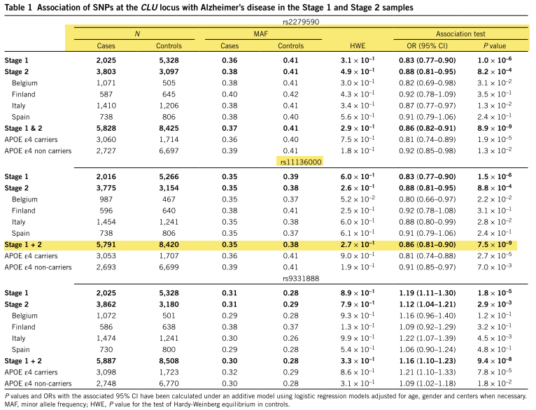

Sample sizes for cases and controls differ from the ones reported in the catalog.

### Risk allele frequency

The RAF and odd ratio reported are not consistent with the catalog.

Therefore, we will use the data provided by the paper for the combined stage (1+2)

|  | 6_rs11136000 |
| --- | --- |
| PUBMEDID | 19734903 |
| LINK | http://europepmc.org/abstract/MED/19734903 |
| STUDY | Genome-wide association study identifies variants at CLU and CR1 associated with Alzheimer’s disease. |
| DISEASE.TRAIT | Alzheimer’s disease |
| INITIAL.SAMPLE.DESCRIPTION | 2,032 European ancestry cases, 5,328 European ancestry controls |
| REPLICATION.SAMPLE.DESCRIPTION | 3,978 European ancestry cases, 3,297 European ancestry controls |
| STRONGEST.SNP_RISK.ALLELE | rs11136000-? |
| SNPS | rs11136000 |
| RISK.ALLELE.FREQUENCY | 0.62 |
| P.VALUE | 8e-09 |
| ORorBETA | 1.16 |
| STAGE | 1+2 \| combined |
| CLINICAL.VARIABLES | NA |
| NOTES | Stratified analysis by populations: Belgium, Finland, Italy and Spain \| flipped odd ratio |
| Sensitivity | 0.654294 |
| Specificity | 0.38 |

|  | Cases | Controls |
| --- | --- | --- |
| ? (+) | 3789 | 5220 |
| ? ( - ) | 2002 | 3200 |
| Total | 5791 | 8420 |

For the remaining SNPs, the same criteria will be used.

# rs2279590 | Alzheimer’s disease

|  | 7_rs2279590 |
| --- | --- |
| PUBMEDID | 19734903 |
| LINK | http://europepmc.org/abstract/MED/19734903 |
| STUDY | Genome-wide association study identifies variants at CLU and CR1 associated with Alzheimer’s disease. |
| DISEASE.TRAIT | Alzheimer’s disease |
| INITIAL.SAMPLE.DESCRIPTION | 2,032 European ancestry cases, 5,328 European ancestry controls |
| REPLICATION.SAMPLE.DESCRIPTION | 3,978 European ancestry cases, 3,297 European ancestry controls |
| STRONGEST.SNP_RISK.ALLELE | rs2279590-? |
| SNPS | rs2279590 |
| RISK.ALLELE.FREQUENCY | 0.59 |
| P.VALUE | 9e-09 |
| ORorBETA | 1.16 |
| STAGE | 1+2 \| combined |
| CLINICAL.VARIABLES | NA |
| NOTES | Stratified analysis by populations: Belgium, Finland, Italy and Spain \| flipped odd ratio \| haplotype analysis not considered for this SNP, just association analysis in CLU locus |
| Sensitivity | 0.6253655 |
| Specificity | 0.41 |

|  | Cases | Controls |
| --- | --- | --- |
| ? (+) | 3645 | 4971 |
| ? ( - ) | 2183 | 3454 |
| Total | 5828 | 8425 |

# rs3818361 | Alzheimer’s disease

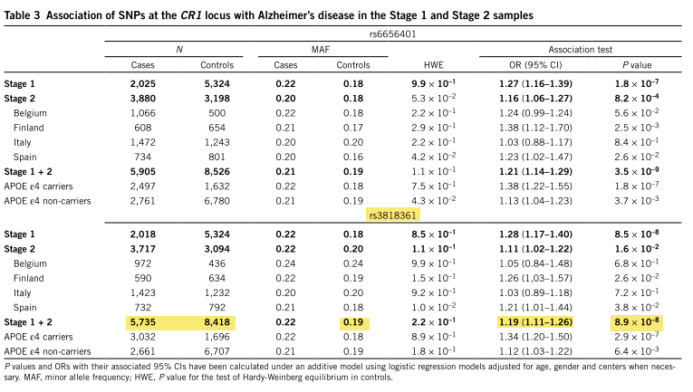

|  | 8_rs3818361 |
| --- | --- |
| PUBMEDID | 19734903 |
| LINK | http://europepmc.org/abstract/MED/19734903 |
| STUDY | Genome-wide association study identifies variants at CLU and CR1 associated with Alzheimer’s disease. |
| DISEASE.TRAIT | Alzheimer’s disease |
| INITIAL.SAMPLE.DESCRIPTION | 2,032 European ancestry cases, 5,328 European ancestry controls |
| REPLICATION.SAMPLE.DESCRIPTION | 3,978 European ancestry cases, 3,297 European ancestry controls |
| STRONGEST.SNP_RISK.ALLELE | rs3818361-? |
| SNPS | rs3818361 |
| RISK.ALLELE.FREQUENCY | 0.19 |
| P.VALUE | 9e-08 |
| ORorBETA | 1.19 |
| STAGE | 1+2 \| combined |
| CLINICAL.VARIABLES | NA |
| NOTES | Stratified analysis by populations: Belgium, Finland, Italy and Spain \| haplotype analysis not considered for this SNP, just association analysis in CR1 locus |
| Sensitivity | 0.2182222 |
| Specificity | 0.81 |

|  | Cases | Controls |
| --- | --- | --- |
| ? (+) | 1252 | 1599 |
| ? ( - ) | 4483 | 6819 |
| Total | 5735 | 8418 |

# rs6656401 | Alzheimer’s disease

|  | 9_rs6656401 |
| --- | --- |
| PUBMEDID | 19734903 |
| LINK | http://europepmc.org/abstract/MED/19734903 |
| STUDY | Genome-wide association study identifies variants at CLU and CR1 associated with Alzheimer’s disease. |
| DISEASE.TRAIT | Alzheimer’s disease |
| INITIAL.SAMPLE.DESCRIPTION | 2,032 European ancestry cases, 5,328 European ancestry controls |
| REPLICATION.SAMPLE.DESCRIPTION | 3,978 European ancestry cases, 3,297 European ancestry controls |
| STRONGEST.SNP_RISK.ALLELE | rs6656401-? |
| SNPS | rs6656401 |
| RISK.ALLELE.FREQUENCY | 0.19 |
| P.VALUE | 4e-09 |
| ORorBETA | 1.21 |
| STAGE | 1+2 \| combined |
| CLINICAL.VARIABLES | NA |
| NOTES | Stratified analysis by populations: Belgium, Finland, Italy and Spain \| haplotype analysis not considered for this SNP, just association analysis in CR1 locus |
| Sensitivity | 0.2210789 |
| Specificity | 0.81 |

|  | Cases | Controls |
| --- | --- | --- |
| ? (+) | 1305 | 1620 |
| ? ( - ) | 4600 | 6906 |
| Total | 5905 | 8526 |

# rs9331888 | Alzheimer’s disease

|  | 10_rs9331888 |
| --- | --- |
| PUBMEDID | 19734903 |
| LINK | http://europepmc.org/abstract/MED/19734903 |
| STUDY | Genome-wide association study identifies variants at CLU and CR1 associated with Alzheimer’s disease. |
| DISEASE.TRAIT | Alzheimer’s disease |
| INITIAL.SAMPLE.DESCRIPTION | 2,032 European ancestry cases, 5,328 European ancestry controls |
| REPLICATION.SAMPLE.DESCRIPTION | 3,978 European ancestry cases, 3,297 European ancestry controls |
| STRONGEST.SNP_RISK.ALLELE | rs9331888-? |
| SNPS | rs9331888 |
| RISK.ALLELE.FREQUENCY | 0.28 |
| P.VALUE | 9e-08 |
| ORorBETA | 1.16 |
| STAGE | 1+2 \| combined |
| CLINICAL.VARIABLES | NA |
| NOTES | Stratified analysis by populations: Belgium, Finland, Italy and Spain \| haplotype analysis not considered for this SNP, just association analysis in CLU locus |
| Sensitivity | 0.3108729 |
| Specificity | 0.72 |

|  | Cases | Controls |
| --- | --- | --- |
| ? (+) | 1830 | 2382 |
| ? ( - ) | 4057 | 6126 |
| Total | 5887 | 8508 |

# rs13387042 | Breast cancer

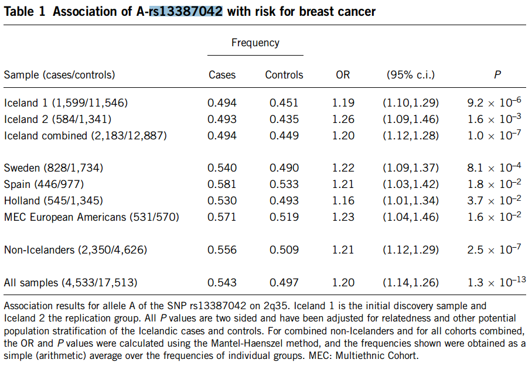

|  | 32_rs13387042 |
| --- | --- |
| PUBMEDID | 17529974 |
| LINK | http://europepmc.org/abstract/MED/17529974 |
| STUDY | Common variants on chromosomes 2q35 and 16q12 confer susceptibility to estrogen receptor-positive breast cancer. |
| DISEASE.TRAIT | Breast cancer |
| INITIAL.SAMPLE.DESCRIPTION | 1,599 European ancestry cases, 11,546 European ancestry controls |
| REPLICATION.SAMPLE.DESCRIPTION | 2,954 European ancestry cases, 5,967 European ancestry controls, Up to 561 Japanese ancestry cases, Up to 565 Japanese ancestry control, Up to 422 African American cases, Up to 448 African American co… |
| STRONGEST.SNP_RISK.ALLELE | rs13387042-A |
| SNPS | rs13387042 |
| RISK.ALLELE.FREQUENCY | 0.5 |
| P.VALUE | 1e-13 |
| ORorBETA | 1.2 |
| STAGE | Combined |
| CLINICAL.VARIABLES | Pathological breast cancer subtypes: Estrogen receptor, progesterone receptor, histopathology(ductal, lobular, ductal vs. lobular), stage, grade |
| NOTES | Stratified analysis from multiethnic cohort: European Americans, Latinas, Hawaiians, Japanese, African Americans \| Allelic interaction analysis |
| Sensitivity | 0.5454545 |
| Specificity | 0.5 |

|  | Cases | Controls |
| --- | --- | --- |
| A (+) | 2473 | 8756 |
| A ( - ) | 2060 | 8756 |
| Total | 4533 | 17513 |

# rs3803662 | Breast cancer

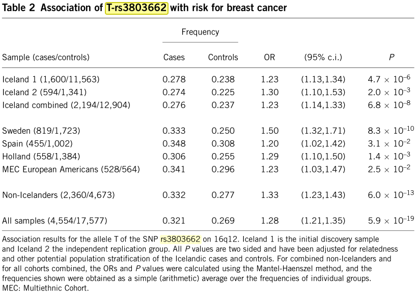

|  | 33_rs3803662 |
| --- | --- |
| PUBMEDID | 17529974 |
| LINK | http://europepmc.org/abstract/MED/17529974 |
| STUDY | Common variants on chromosomes 2q35 and 16q12 confer susceptibility to estrogen receptor-positive breast cancer. |
| DISEASE.TRAIT | Breast cancer |
| INITIAL.SAMPLE.DESCRIPTION | 1,599 European ancestry cases, 11,546 European ancestry controls |
| REPLICATION.SAMPLE.DESCRIPTION | 2,954 European ancestry cases, 5,967 European ancestry controls, Up to 561 Japanese ancestry cases, Up to 565 Japanese ancestry control, Up to 422 African American cases, Up to 448 African American co… |
| STRONGEST.SNP_RISK.ALLELE | rs3803662-T |
| SNPS | rs3803662 |
| RISK.ALLELE.FREQUENCY | 0.27 |
| P.VALUE | 6e-19 |
| ORorBETA | 1.28 |
| STAGE | Combined |
| CLINICAL.VARIABLES | Pathological breast cancer subtypes: Estrogen receptor, progesterone receptor, histopathology(ductal, lobular, ductal vs. lobular), stage, grade |
| NOTES | Stratified analysis from multiethnic cohort: European Americans, Latinas, Hawaiians, Japanese, African Americans \| Allelic interaction analysis |
| Sensitivity | 0.321309 |
| Specificity | 0.73 |

|  | Cases | Controls |
| --- | --- | --- |
| T (+) | 1463 | 4746 |
| T ( - ) | 3091 | 12831 |
| Total | 4554 | 17577 |

# rs2180341 | Breast cancer

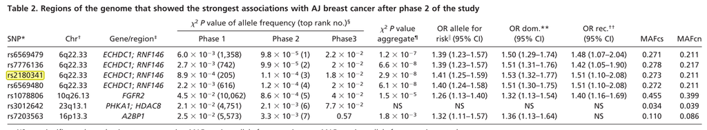

|  | 34_rs2180341 |
| --- | --- |
| PUBMEDID | 18326623 |
| LINK | http://europepmc.org/abstract/MED/18326623 |
| STUDY | Genome-wide association study provides evidence for a breast cancer risk locus at 6q22.33. |
| DISEASE.TRAIT | Breast cancer |
| INITIAL.SAMPLE.DESCRIPTION | 249 Ashkenazi Jewish ancestry non-BRCA1/2 carriers cases, 299 Ashkenazi Jewish ancestry non-BRCA1/2 carriers controls |
| REPLICATION.SAMPLE.DESCRIPTION | 1,193 Ashkenazi Jewish ancestry non-BRCA1/2 carriers cases,1,166 Ashkenazi Jewish ancestry non-BRCA1/2 carriers controls |
| STRONGEST.SNP_RISK.ALLELE | rs2180341-G |
| SNPS | rs2180341 |
| RISK.ALLELE.FREQUENCY | 0.21 |
| P.VALUE | 3e-08 |
| ORorBETA | 1.41 |
| STAGE | 1+2+3 \| combined |
| CLINICAL.VARIABLES | NA |
| NOTES | NA |
| Sensitivity | 0.2726268 |
| Specificity | 0.79 |

|  | Cases | Controls |
| --- | --- | --- |
| G (+) | 393 | 308 |
| G ( - ) | 1049 | 1157 |
| Total | 1442 | 1465 |

# rs2046210 | Breast cancer

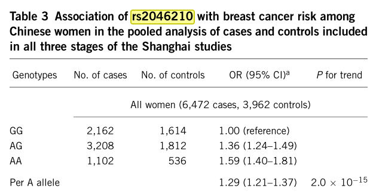

|  | 35_rs2046210 |
| --- | --- |
| PUBMEDID | 19219042 |
| LINK | http://europepmc.org/abstract/MED/19219042 |
| STUDY | Genome-wide association study identifies a new breast cancer susceptibility locus at 6q25.1. |
| DISEASE.TRAIT | Breast cancer |
| INITIAL.SAMPLE.DESCRIPTION | 1,505 Chinese ancestry cases, 1,522 Chinese ancestry controls |
| REPLICATION.SAMPLE.DESCRIPTION | 5,026 Chinese ancestry cases, 2,476 Chinese ancestry controls, 1,591 European ancestry cases, 1,466 European ancestry controls |
| STRONGEST.SNP_RISK.ALLELE | rs2046210-A |
| SNPS | rs2046210 |
| RISK.ALLELE.FREQUENCY | 0.37 |
| P.VALUE | 2e-15 |
| ORorBETA | 1.29 |
| STAGE | 1+2+3 \| combined |
| CLINICAL.VARIABLES | Age \| Education \| Age at menarche \| Postmenopausal (%) \| Age at menopause \| Number of Live Births \| Age at first live birth \| Used HRT-Hormone replacement therapy (%) \| Breast cancer family hi… |
| NOTES | NA |
| Sensitivity | 0.4310485 |
| Specificity | 0.63 |

|  | Cases | Controls |
| --- | --- | --- |
| A (+) | 2790 | 1466 |
| A ( - ) | 3682 | 2496 |
| Total | 6472 | 3962 |

# rs10197940 | Lung cancer

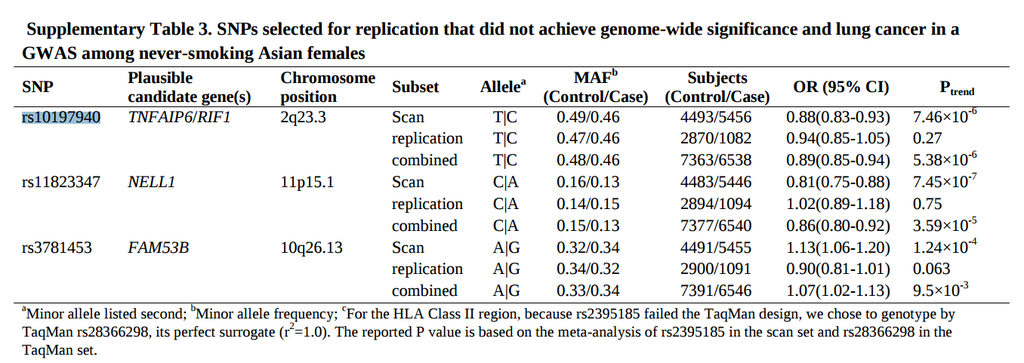

|  | 219_rs10197940 |
| --- | --- |
| PUBMEDID | 23143601 |
| LINK | http://europepmc.org/abstract/MED/23143601 |
| STUDY | Genome-wide association analysis identifies new lung cancer susceptibility loci in never-smoking women in Asia. |
| DISEASE.TRAIT | Lung cancer |
| INITIAL.SAMPLE.DESCRIPTION | 5,510 East Asian ancestry cases, 4,544 East Asian ancestry controls |
| REPLICATION.SAMPLE.DESCRIPTION | 1,099 East Asian ancestry cases, 2,913 East Asian ancestry controls |
| STRONGEST.SNP_RISK.ALLELE | rs10197940-T |
| SNPS | rs10197940 |
| RISK.ALLELE.FREQUENCY | 0.52 |
| P.VALUE | 5e-06 |
| ORorBETA | 1.12 |
| STAGE | 1+2 \| combined \| scan + replication |
| CLINICAL.VARIABLES | NA |
| NOTES | flipped odd ratio \| complementary RAF |
| Sensitivity | 0.5481928 |
| Specificity | 0.48 |

|  | Cases | Controls |
| --- | --- | --- |
| T (+) | 3584 | 3829 |
| T ( - ) | 2954 | 3534 |
| Total | 6538 | 7363 |

# rs2395185 | Lung cancer

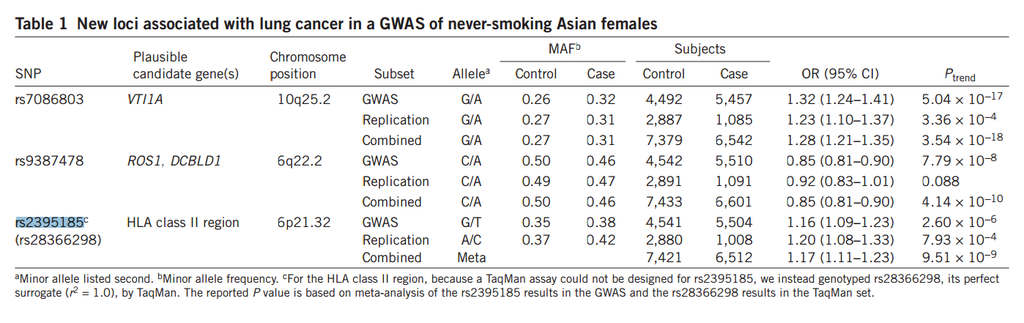

|  | 220_rs2395185 |
| --- | --- |
| PUBMEDID | 23143601 |
| LINK | http://europepmc.org/abstract/MED/23143601 |
| STUDY | Genome-wide association analysis identifies new lung cancer susceptibility loci in never-smoking women in Asia. |
| DISEASE.TRAIT | Lung cancer |
| INITIAL.SAMPLE.DESCRIPTION | 5,510 East Asian ancestry cases, 4,544 East Asian ancestry controls |
| REPLICATION.SAMPLE.DESCRIPTION | 1,099 East Asian ancestry cases, 2,913 East Asian ancestry controls |
| STRONGEST.SNP_RISK.ALLELE | rs2395185-T |
| SNPS | rs2395185 |
| RISK.ALLELE.FREQUENCY | 0.35 |
| P.VALUE | 1e-08 |
| ORorBETA | 1.17 |
| STAGE | 1 |
| CLINICAL.VARIABLES | NA |
| NOTES | Due to missing allele frequencies for combined stage, first stage was considered |
| Sensitivity | 0.3865031 |
| Specificity | 0.65 |

|  | Cases | Controls |
| --- | --- | --- |
| T (+) | 2127 | 1589 |
| T ( - ) | 3377 | 2952 |
| Total | 5504 | 4541 |

# rs7086803 | Lung cancer

[output not shown]

|  | Cases | Controls |
| --- | --- | --- |
| A (+) | 1753 | 1213 |
| A ( - ) | 3704 | 3279 |
| Total | 5457 | 4492 |

# rs9387478 | Lung cancer

|  | 226_rs9387478 |
| --- | --- |
| PUBMEDID | 23143601 |
| LINK | http://europepmc.org/abstract/MED/23143601 |
| STUDY | Genome-wide association analysis identifies new lung cancer susceptibility loci in never-smoking women in Asia. |
| DISEASE.TRAIT | Lung cancer |
| INITIAL.SAMPLE.DESCRIPTION | 5,510 East Asian ancestry cases, 4,544 East Asian ancestry controls |
| REPLICATION.SAMPLE.DESCRIPTION | 1,099 East Asian ancestry cases, 2,913 East Asian ancestry controls |
| STRONGEST.SNP_RISK.ALLELE | rs9387478-C |
| SNPS | rs9387478 |
| RISK.ALLELE.FREQUENCY | 0.5 |
| P.VALUE | 4e-10 |
| ORorBETA | 1.18 |
| STAGE | 1+2 \| combined |
| CLINICAL.VARIABLES | NA |
| NOTES | flipped odd ratio \| The primary analysis was performed using logistic regression for genotype trend effect (with 1 degree of freedom) adjusted for study center, age and three eigenvectors (on the bas… |
| Sensitivity | 0.5412844 |
| Specificity | 0.5 |

|  | Cases | Controls |
| --- | --- | --- |
| C (+) | 3573 | 3716 |
| C ( - ) | 3028 | 3716 |
| Total | 6601 | 7433 |

# rs2736100 | Lung cancer

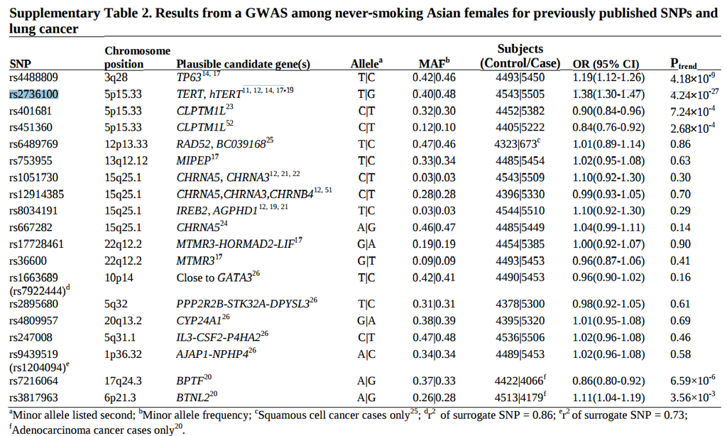

|  | 221_rs2736100 |
| --- | --- |
| PUBMEDID | 23143601 |
| LINK | http://europepmc.org/abstract/MED/23143601 |
| STUDY | Genome-wide association analysis identifies new lung cancer susceptibility loci in never-smoking women in Asia. |
| DISEASE.TRAIT | Lung cancer |
| INITIAL.SAMPLE.DESCRIPTION | 5,510 East Asian ancestry cases, 4,544 East Asian ancestry controls |
| REPLICATION.SAMPLE.DESCRIPTION | 1,099 East Asian ancestry cases, 2,913 East Asian ancestry controls |
| STRONGEST.SNP_RISK.ALLELE | rs2736100-G |
| SNPS | rs2736100 |
| RISK.ALLELE.FREQUENCY | 0.4 |
| P.VALUE | 4e-27 |
| ORorBETA | 1.38 |
| STAGE | 1 |
| CLINICAL.VARIABLES | NA |
| NOTES | The primary analysis was performed using logistic regression for genotype trend effect (with 1 degree of freedom) adjusted for study center, age and three eigenvectors (on the basis of principal-compo… |
| Sensitivity | 0.4791667 |
| Specificity | 0.6 |

|  | Cases | Controls |
| --- | --- | --- |
| G (+) | 2638 | 1817 |
| G ( - ) | 2867 | 2726 |
| Total | 5505 | 4543 |

# rs4488809 | Lung cancer

|  | 223_rs4488809 |
| --- | --- |
| PUBMEDID | 23143601 |
| LINK | http://europepmc.org/abstract/MED/23143601 |
| STUDY | Genome-wide association analysis identifies new lung cancer susceptibility loci in never-smoking women in Asia. |
| DISEASE.TRAIT | Lung cancer |
| INITIAL.SAMPLE.DESCRIPTION | 5,510 East Asian ancestry cases, 4,544 East Asian ancestry controls |
| REPLICATION.SAMPLE.DESCRIPTION | 1,099 East Asian ancestry cases, 2,913 East Asian ancestry controls |
| STRONGEST.SNP_RISK.ALLELE | rs4488809-C |
| SNPS | rs4488809 |
| RISK.ALLELE.FREQUENCY | 0.42 |
| P.VALUE | 4e-09 |
| ORorBETA | 1.19 |
| STAGE | 1 |
| CLINICAL.VARIABLES | NA |
| NOTES | The primary analysis was performed using logistic regression for genotype trend effect (with 1 degree of freedom) adjusted for study center, age and three eigenvectors (on the basis of principal-compo… |
| Sensitivity | 0.4628635 |
| Specificity | 0.58 |

|  | Cases | Controls |
| --- | --- | --- |
| C (+) | 2523 | 1887 |
| C ( - ) | 2927 | 2606 |
| Total | 5450 | 4493 |

# rs7216064 | Lung cancer

|  | 225_rs7216064 |
| --- | --- |
| PUBMEDID | 23143601 |
| LINK | http://europepmc.org/abstract/MED/23143601 |
| STUDY | Genome-wide association analysis identifies new lung cancer susceptibility loci in never-smoking women in Asia. |
| DISEASE.TRAIT | Lung cancer |
| INITIAL.SAMPLE.DESCRIPTION | 5,510 East Asian ancestry cases, 4,544 East Asian ancestry controls |
| REPLICATION.SAMPLE.DESCRIPTION | 1,099 East Asian ancestry cases, 2,913 East Asian ancestry controls |
| STRONGEST.SNP_RISK.ALLELE | rs7216064-A |
| SNPS | rs7216064 |
| RISK.ALLELE.FREQUENCY | 0.63 |
| P.VALUE | 7e-06 |
| ORorBETA | 1.16 |
| STAGE | 1 |
| CLINICAL.VARIABLES | NA |
| NOTES | flipped odd ratio \| complementary RAF \| The primary analysis was performed using logistic regression for genotype trend effect (with 1 degree of freedom) adjusted for study center, age and three eig… |
| Sensitivity | 0.6638808 |
| Specificity | 0.37 |

|  | Cases | Controls |
| --- | --- | --- |
| A (+) | 2699 | 2786 |
| A ( - ) | 1367 | 1636 |
| Total | 4066 | 4422 |

# rs10520045 | Major depressive disorder

> After excluding SNPs not present on the HumanHap 550v3 chip used for the control samples, the final data set comprised 491,238 autosomal markers from 597 cases and 1295 control subjects. This number of SNPs corresponds to 79% of the 620,901 SNPs genotyped per patient. The replication sample consisted of 409 inpatients (179 men, 230 women) and 541 German control subjects matched to provide an equivalent distribution of age and sex

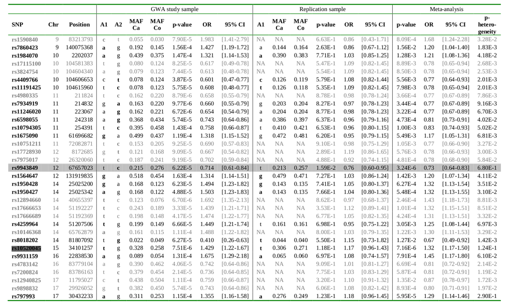

|  | 238_rs10520045 |
| --- | --- |
| PUBMEDID | 20673876 |
| LINK | http://europepmc.org/abstract/MED/20673876 |
| STUDY | Genome-wide association-, replication-, and neuroimaging study implicates HOMER1 in the etiology of major depression. |
| DISEASE.TRAIT | Major depressive disorder |
| INITIAL.SAMPLE.DESCRIPTION | 597 European ancestry cases, 1,295 European ancestry controls |
| REPLICATION.SAMPLE.DESCRIPTION | 409 European ancestry cases, 541 European ancestry controls |
| STRONGEST.SNP_RISK.ALLELE | rs10520045-T |
| SNPS | rs10520045 |
| RISK.ALLELE.FREQUENCY | 0.27 |
| P.VALUE | 7e-06 |
| ORorBETA | 1.32 |
| STAGE | 1 + 2 \| combined \| study + replication |
| CLINICAL.VARIABLES | Working memory task \| Implicit emotion recognition task \| Reward anticipation task \| Functional magnetic resonance imaging (fMRI) |
| NOTES | Sum of study cohort and replication individuals to get sample sizes for controls and cases |
| Sensitivity | 0.328056 |
| Specificity | 0.73 |

|  | Cases | Controls |
| --- | --- | --- |
| T (+) | 330 | 496 |
| T ( - ) | 676 | 1340 |
| Total | 1006 | 1836 |

# Sensitivity - Specificity plot

```r
curated_gwas <- subset(assoc, !is.na(CASES))

senses <- SenSes(
    curated_gwas[,c('CASES', 'CONTROLS', 'RISK.ALLELE.FREQUENCY', 'ORorBETA')]
    )

curated_gwas_senses <- cbind(curated_gwas, senses)
# plot(curated_gwas_senses$Specificity, curated_gwas_senses$Sensitivity,
#      main = "Specificity vs. Sensitivity for GWA studies",
#      xlab = "1- Specificity", ylab = "Sensitivity", xlim = c(0, 1), ylim = c(0, 1))
# text(curated_gwas_senses$Specificity, curated_gwas_senses$Sensitivity,
#       row.names(curated_gwas_senses), cex=0.6, pos=4, col="blue")
# # text(1- curated_gwas_senses$Specificity, curated_gwas_senses$Sensitivity,
# #      curated_gwas_senses$RISK.ALLELE.FREQUENCY, cex=0.6, pos=1, col="blue")
# abline(0, 1, col = "red", lty=2)
```

```r
library('rCharts')
dP <- dPlot(
  Sensitivity ~ Specificity,
  groups = c("SNPS","RISK.ALLELE.FREQUENCY", "P.VALUE", "ORorBETA", "DISEASE.TRAIT"),
  data = curated_gwas_senses,
  type = "bubble",
  height = 650,
  width = 800

)
dP$xAxis(type = "addMeasureAxis", overrideMax = 1, outputFormat = ".2f")
dP$yAxis(overrideMax = 1, outputFormat = ".2f")
dP$legend(
   x = 200,
   y = 10,
   width = 400,
   height = 20,
   horizontalAlign = "right"
   )

dP$setTemplate(
  afterScript = sprintf(
'<script>
var line = d3.svg.line()
  .x(function(d) { return myChart.axes[0]._draw.scale()(d.x); })
  .y(function(d) { return myChart.axes[1]._draw.scale()(d.y); });

d3.select("#%s svg g")
  .append("path")
  .datum([{x:myChart.axes[0]._min,y:0},{x:myChart.axes[0]._max,y:1}])
  .attr("d",line)
  .style("stroke", "red")
  .style("stroke-width",0.5)
  .style("stroke-dasharray", "2");
</script>
',
dP$params$dom
))

dP$save('specificity-sensitivity_plot.html', cdn = TRUE)
cat('<a href=specificity-sensitivity_plot.html> specificity-sensitivity plot</a>')
```

specificity-sensitivity plot

```r
# Ensure reproducibility
options(width = 120)
```

```
##  setting  value
##  version  R version 3.2.0 (2015-04-16)
##  system   x86_64, linux-gnu
##  ui       X11
##  language en_US
##  collate  en_US.UTF-8
##  tz       <NA>
```

```
## Packages ---------------------------------------------------------------------------------------------------------------
```

```
##  package    * version date       source
##  devtools   * 1.7.0   2015-01-17 CRAN (R 3.2.0)
##  digest     * 0.6.8   2014-12-31 CRAN (R 3.2.0)
##  evaluate   * 0.7     2015-04-21 CRAN (R 3.2.0)
##  formatR    * 1.2     2015-04-21 CRAN (R 3.2.0)
##  highr      * 0.5     2015-04-21 CRAN (R 3.2.0)
##  htmltools  * 0.2.6   2014-09-08 CRAN (R 3.2.0)
##  knitr        1.10.5  2015-05-06 CRAN (R 3.2.0)
##  lattice    * 0.20-31 2015-03-30 CRAN (R 3.1.3)
##  magrittr   * 1.5     2014-11-22 CRAN (R 3.2.0)
##  plyr       * 1.8.2   2015-04-21 CRAN (R 3.2.0)
##  rCharts      0.4.5   2015-05-09 Github (ramnathv/rCharts@389e214)
##  Rcpp       * 0.11.6  2015-05-01 CRAN (R 3.2.0)
##  rjson      * 0.2.15  2014-11-03 CRAN (R 3.2.0)
##  RJSONIO    * 1.3-0   2014-07-28 CRAN (R 3.2.0)
##  rmarkdown  * 0.6.1   2015-05-07 CRAN (R 3.2.0)
##  rstudioapi * 0.3.1   2015-04-07 CRAN (R 3.2.0)
##  stringi    * 0.4-1   2014-12-14 CRAN (R 3.2.0)
##  stringr    * 1.0.0   2015-04-30 CRAN (R 3.2.0)
##  whisker    * 0.3-2   2013-04-28 CRAN (R 3.2.0)
##  yaml       * 2.1.13  2014-06-12 CRAN (R 3.2.0)
```